# Class 3: Social Movement Theories

Framing, civil society

[Dr. Michael C. Zeller](https://michaelzeller.de)

# Opening notes

[Open Sticker](https://tenor.com/view/open-gif-14209777)from [Open Stickers](https://tenor.com/search/open-stickers)

- please try to do the readings assigned for the week *prior to that week’s class*

## Movements in the news

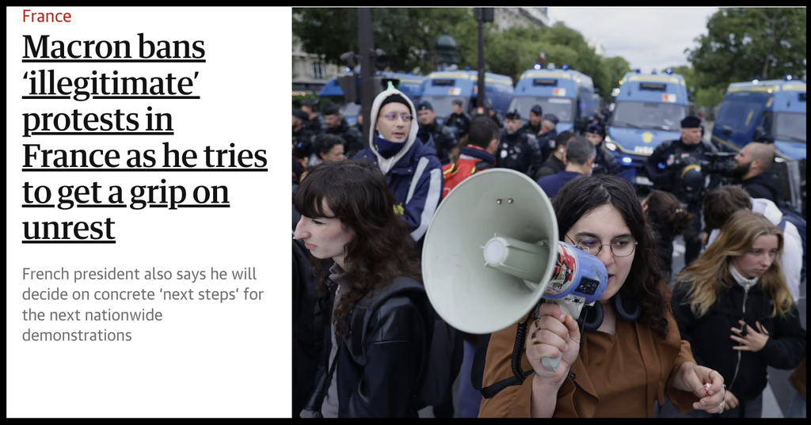

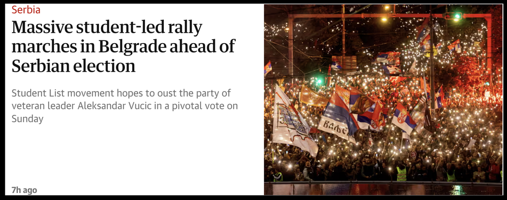

## Presentation groups

Remember: topic to me at least by Week 4

- December
- January

Presentations line-up

| Date | Presenters | Method |
| --- | --- | --- |
| 7 Dec: |  | TBD |
| 14 Dec: |  | TBD |
| 21 Dec: |  | TBD |

Presentations line-up

| Date | Presenters | Method |
| --- | --- | --- |
| 11 Jan: |  | TBD |
| 18 Jan: |  | TBD |
| 25 Jan: |  | TBD |

# Assigning groups for in-depth study

[figure not shown]

To get assigned a group to study in depth, scan the QR code or click this **[LINK](https://script.google.com/macros/s/AKfycbwCEr23kuMmKbZV3hyzBuCchjwT5aldL8rgF0pr0GnFiNtcc4je_8C0U6t9shoPMW5h/exec)**

You will be randomly assigned one of these groups:

- Antifa
- FFF - Fridays for Future
- LG - Letzte Generation
- PEGIDA
- Identitarians
- Querdenker

# Social movement theories covered so far

- Collective behaviour theory
- Resource mobilisation theory
- Political process theory

[David Mitchell Theory GIF](https://tenor.com/view/david-mitchell-theory-wilty-that%27s-what-i-thought-guess-gif-4485172671334812188)from [David Mitchell GIFs](https://tenor.com/search/david+mitchell-gifs)

## Recall overview from Tarrow (2011)

| Parent Scholarship | Social Movement Studies (SMS) |
| --- | --- |
| Marx and Engels, class conflict | Collective behaviour theory |
| structuralist (leaves little room for the mechanisms that actually draw individuals in collective action) | (grievances, [relative] deprivation) |
| legacy for SMS: class forces and other cleavages spurring collective action |  |
| Lenin and resource mobilisation | Resource mobilisation theory |
| vanguardism |  |
| legacy for SMS: focus on leaders/organisers (mobilising interests) and organisations | leadership, organisations, and various resources |
| Gramsci and cultural hegemony | Framing and Collective identity theories |
| counterculture of working class can overcome bourgeois hegemonic culture | 'cultural turn' (from anthropology, sociology) |
| legacy for SMS: constructivism, prefiguration, and movement impact on culture | forming consensus in movements |
| Tilly's Polity Model | Political process theory |
| the structure of the state/polity | opportunities, constraints, and the structure of contentious politics |
| legacy for SMS: repertoires of contention, WUNC (worthiness, unity, numbers, committed) |  |

# Framing

- background: the ‘cultural turn’
- main types of frames: *diagnostic*, *prognostic*, *motivational*
- other types of frames: *injustice*, *master frame*, *counter frame*
- framing dynamics: *framing contest*, *frame bridging*, *frame amplification*, *frame extension*, *frame transformation*, *frame resonance*

[The Office Pam Beesly GIF](https://tenor.com/view/the-office-pam-beesly-im-gonna-frame-it-i-am-gonna-frame-it-frame-it-gif-21676839)from [The Office GIFs](https://tenor.com/search/the+office-gifs)

## The ‘cultural turn’ and new social movements

- origins: Gramscian concentration on internal life of movements, values and meaning-making; otherwise the central contribution of ‘new social movements’ is missed
- some key scholars: E. Goffmann, A. Melucci, F. Polletta, J. Jasper, R. Benford, D. Snow
- key concepts:
  - collective identity
  - emotions
  - framing

framing

emotion work

identity construction

## The ‘cultural turn’ and new social movements

- origins: Gramscian concentration on internal life of movements, values and meaning-making; otherwise the central contribution of ‘new social movements’ is missed
- some key scholars: E. Goffmann, A. Melucci, F. Polletta, J. Jasper, R. Benford, D. Snow
- key concepts:
  - collective identity
  - emotions
  - framing

framing

emotion work

identity construction

movement solidarity

## Framing - definition and origins

- broadly, **framing** refers to the meanings individuals or groups attach to events, developments, activities, and other individuals/groups.
  - previously, this had also been covered by referring to **ideology**
- origins of ‘framing’: Erving Goffman’s *Frame Analysis* (1974)
  - frames link **objective conditions** to **subjective perceptions**
- Benford and Snow (1986) connect this concept to social movements
  - how do collective actors collectively determine *what’s going on here* — and once they make that determination, how do they try to convince others?

## Framing - why?

- Is there a problem?
- Can it be fixed?
- How can it be fixed?
- What must be done?
- **Frames provide answers to these questions—they are essential to movement activity**

## Framing - why?

- Is there a problem?
- Can it be fixed?
- How can it be fixed?
- What must be done?
- **Frames provide answers to these questions—they are essential to movement activity**
- types of **frames**:
  - *diagnostic*: what’s the problem and who’s to blame
  - *prognostic*: how can the problem be solved
  - *motivational*: why should we go solve this problem

## Framing - an example

- types of **frames**: *diagnostic*: what’s the problem and who’s to blame; *prognostic*: how can the problem be solved; *motivational*: why should we go solve this problem

*deaths from drunk driving*

- previously, ‘just’ sad, but bound to happen, like other accidents
- But then (re-)framed:
  - Some immoral person drank and drove
  - People should not drive drunk
  - It is not fair for a person to die because of another’s immorality
- Examples from cases you know: how do movements frame issues?

## Injustice frames (Gamson, 2013)

- When impersonal, abstract forces are perceived as responsible for problems/wrongs/suffering, people tend to accept, tolerate, and cope

BUT…

- When problems/wrongs/suffering are attributed to individuals’ or groups’ *ignorance*, *indifference*, or *malice*, the result is a **sense of injustice**

Injustice frames are often the core of **diagnosing** issues that movements care about

## Further types of frames

- **Master frame**: an overarching frame that smaller/sub-issue frames fit into
  - e.g., the ‘Great Replacement’
    - can accommodate subordinate frames about welfare provision, ethno-cultural identity, maintaining liberal democracy, religious heritage and/or freedom, etc.

## Further types of frames

- **Counter frame**: a frame created to oppose another group’s frame (cf. Mayer 1995; Meyer and Staggenborg 1996, 2008)
  - e.g., abortion contention in the U.S.:
    - one side: ‘*pro-choice*’, freedom to choose to abort or not
    - other side: ’where is the baby’s *choice*? (rights of unborn)

## Further types of frames

- **Counter frame**: a frame created to oppose another group’s frame (cf. Mayer 1995; Meyer and Staggenborg 1996, 2008)
  - e.g., abortion contention in the U.S.:
    - one side: ‘*pro-choice*’, freedom to choose to abort or not
    - other side: ’where is the baby’s *choice*? (rights of unborn)
    - one side: women’s *right*
    - other side: *regret* of women who have aborted
- ‘framing contest’ – which frame is doing better among opposing movements
  - this is traceable/measureable in different arenas: mass media, political debates, court cases, etc.

## Framing contest (Alex Wong, Getty Images)

[figure not shown]

other examples?

## Frame alignment (Benford and Snow 2000)

- **frame bridging** - linking of two or more ideologically congruent but structurally unconnected frames regarding a particular issue or problem
  - e.g., German activists against World Bank and IMF, linking their frames to those of peace, ecosystem, women’s, localism, and labour movements
- **frame amplification** - idealization, embellishment, clarification, or invigoration of existing values or beliefs
  - e.g., white supremacists stressing ‘white *pride*’ or preserving white race (e.g., 14 words)

## Frame alignment (Benford and Snow 2000)

- **frame extension** - depicting an SMO’s interests and frame(s) as extending beyond its primary interests to include issues and concerns that are presumed to be of importance to potential adherents
  - e.g., peace movement: money spent on military could be used for education, infrastructure, social programmes, etc. — so groups that want more funding are potential recruits
- **frame transformation** - changing old understandings and meanings and/or generating new ones
  - e.g., drunk driving example: accident → moral failing

## Frame resonance (Benford and Snow 2000)

> resonance - degree to which a movement’s framing aligns with beliefs, values, experiences of consituents/audience/public
- **Credibility**:
  - *consistency* - congruency of SMO’s beliefs, claims, and actions
    - e.g., do Klima-Kleber actions align with claims?
  - *empirical credibility* - can claims be verified
    - e.g., climate change: complex, but measurable and traceable
  - *credibility of claim-maker* - are the movement actors (esp. leaders) seen as reliable, knowledgeable, respectable
    - e.g., we should listen to Einstein and Sakharov about nuclear disarmament because they understand how the bombs work

## Frame resonance (Benford and Snow 2000)

> resonance - degree to which a movement’s framing aligns with beliefs, values, experiences of consituents/audience/public
- **Salience**:
  - *centrality* - does it **matter** to potential members/participants?
  - *experiential commensurability* - does it fit with the experience of potential members/participants?
  - *narrative fidelity* - does it accord with wider cultural narratives/traditions?

## Transnational framing example (Tronina 2026)

Tronina (2026) looks at anti-gender social movement organisations’ (SMOs) activity online

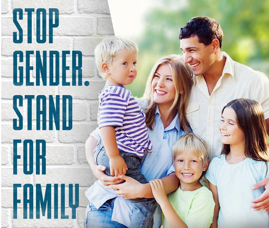

[figure not shown]

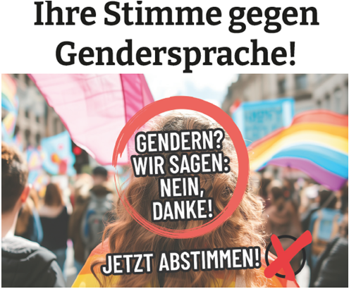

[figure not shown]

transnational set of SMOs campaigning against ‘gender’ (e.g., framing it in opposition to ‘family’)

likening **gender** and **LGBT** to ‘profanity’ and ‘propaganda’

frames specific to local context (e.g., gendering in German)

and connecting online frames to offline actions

investigating this activity through Twitter/X accounts of SMOs in Croatia (9), Germany (26), France (41), Italy (43), and Poland (29)

## Transnational framing example (Tronina 2026)

Most Transnationally Connective Hashtags Per Year

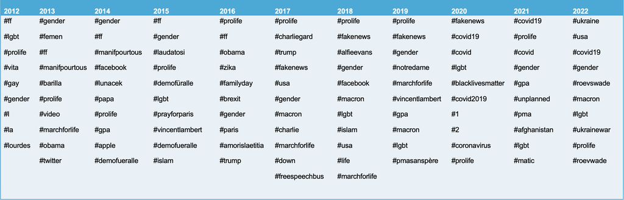

## Transnational framing example (Tronina 2026)

Most Transnationally Connective Hashtags Per Year

*Dissemination* - getting the word out

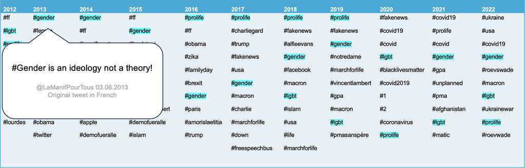

## Transnational framing example (Tronina 2026)

Most Transnationally Connective Hashtags Per Year

*Dissemination* - getting the word out

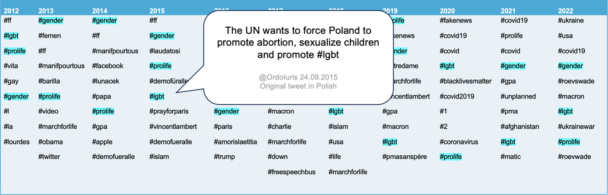

## Transnational framing example (Tronina 2026)

Most Transnationally Connective Hashtags Per Year

*Mobilisation*

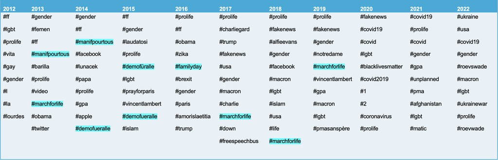

## Transnational framing example (Tronina 2026)

Most Transnationally Connective Hashtags Per Year

*Extension* - connecting to other issues

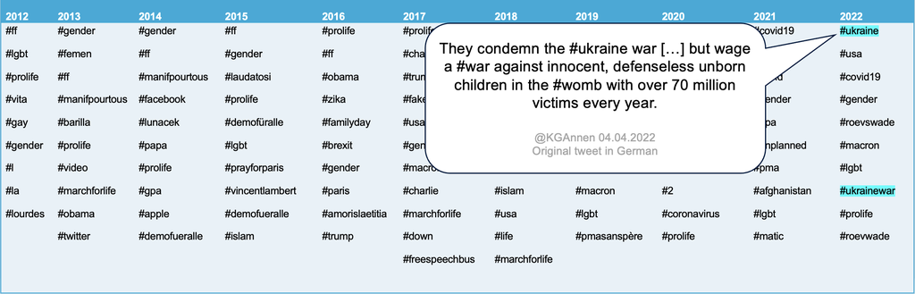

Check out Tronina’s (2026) article for more!

## Further on framing… interview with William Gamson:

[video not shown]

# Poll: framing, SMs/CSOs, democracy

[figure not shown]

Take the survey at **https://forms.gle/zTF1dhs9whMV5H5t7**

- Do movements always challenge dominant frames within a society?
- Does ‘frame bridging’ increase a movement’s chances of having an impact?
- Do framing strategies differ significantly in authoritarian vs. democratic regimes?
- Movement activism is a good thing for democratic societies
- A large civil society, with many citizens participating in voluntary associations, is beneficial for liberal democratic political systems

[interactive chart not shown]

Do movements always challenge dominant frames within a society?

[interactive chart not shown]

Does *frame bridging* increase a movement’s chances of having an impact?

[interactive chart not shown]

# Open data - FR framing of COVID-19

- Table
- Bar chart
- Explanatory note

| Organisation | Ideological strand | Followers (22 Apr 2020) | Posts (22 Feb-22 Apr 2020) | COVID-19 posts | % COVID-19 | First COVID-19 post |
| --- | --- | --- | --- | --- | --- | --- |
| Identitäre Bewegung Deutschland | Identitarian | 5808 | 60 | 13 | 21.7 | 2020-03-13 |
| Génération Identitaire | Identitarian | 1888 | 54 | 12 | 22.2 | 2020-03-26 |
| Hundred Handers | Identitarian | 4238 | 135 | 35 | 25.9 | 2020-03-21 |
| CasaPound Italia | National Socialist | 4710 | 173 | 82 | 47.4 | 2020-02-24 |
| Nordic Resistance Movement | National Socialist | 1117 | 81 | 20 | 24.7 | 2020-02-25 |
| British National Socialist Movement | National Socialist | 825 | 422 | 47 | 11.1 | 2020-02-25 |

[interactive chart not shown]

The data represented on this slide comes from McNeil-Willson’s 2020 article on far-right movement organisations’ framing activities on social media during the early stages of the COVID-19 pandemic.

Data source: McNeil-Willson, R. (2020) “Framing in times of crisis: Responses to COVID-19 amongst Far Right movements and organisations”, ICCT Research Paper. Full text: https://icct.nl/publication/framing-times-crisis-responses-covid-19-amongst-far-right-movements-and-organisations

# Civil society: An alternative approach to understand social movements?

- concept of civil society
- civil society and democracy
- (un)civil society (Berman 1997)

[Without People Like Me Civil Society Collapses Completely Liz Lemon GIF](https://tenor.com/view/without-people-like-me-civil-society-collapses-completely-liz-lemon-tina-fey-30rock-people-like-me-holds-this-society-together-gif-21957116)from [Without People Like Me Civil Society Collapses Completely GIFs](https://tenor.com/search/without+people+like+me+civil+society+collapses+completely-gifs)

## Introducing concept of civil society

- **civil society**: organised (non-state, non-market) societal activity
  - composed of *voluntary association* based on *shared interests*
  - fuzzy conceptual boundaries
  - *Bolleyer*: voluntary members, non-profit, private, self-governing, formalised infrastructure
- Alexis de Tocqueville: **free association** essential for democracy
- other perspectives on **civil society** concept:
  - social contract theory: surrender of (some) freedom for civil(ised) society — escaping ‘state of nature’
  - Marxian: dissolution of civil society in favour of state
  - Gramscian: part of arena for battling for *cultural hegemony*

## Larry Diamond on civil society and democracy (until 2.20):

[video not shown]

- 1. monitoring government performance; (ii) mobilising political participation (voting is bare minimum—democracy needs more engagement); (iii) force [parties] to become more democratic internally; (iv) form coalitions to push through reforms

*so lots of parallels with conceptions of social movement sector*

## Civil society and democracy

- organisational participation (contributing to democratic citizenry)
- interest representation (similar function to parties)
- societal responsiveness (alternative mechanism of political input)

## Civil society and democracy

- organisational participation (contributing to democratic citizenry)
- interest representation (similar function to parties)
- societal responsiveness (alternative mechanism of political input)

↓

**democratic culture**

- BUT… assumption that political engagement is democratically positive
- is this a *fair weather* theory: civil society contributes to democracy only in already healthy democratic settings? Can it combat strains/crises?

## Movements/Civil society and Democracy

- movement activism *good* for democracy

[interactive chart not shown]

large civil society is beneficial for liberal democracy

[interactive chart not shown]

## Berman (1997) - Civil society in Weimar - theory

- Tocqueville
  - neo-Tocquevillian scholars: Putnam’s focus on community and social capital (e.g., *Bowling Alone*)
    - **associationism** both indicator of healthy democracy and prerequisite for it
- W. Kornhauser, H. Arendt: ‘mass society’ (collapse of intermediate associations)
  - industrialisation and modernity estranged citizens from each other — lack of *belonging*

## Theory puzzle

- neo-Tocquevillean theories:
  - high levels of associationism = good for democracy
- Huntingtonian institutionalist theories:
  - without high **political institutionalisation**, active and mobilised citizenry degenerates into instability, disorder, and even violence

## Types of puzzles (Day and Koivu 2019)

- Empirical puzzles
  - Contra expectations - against conventional wisdom or theoretical expectation
    - e.g., Soviet liberalisation and disintegration—no one expected it!
  - Divergence/convergence - (D) multiple cases that look similar experience different outcomes; (C) multiple cases that look different experience the same outcome
    - e.g., (D) post-Soviet transition – looks the same, but…
    - e.g., (C) third wave of democratisation - Portugal, Latin America, Philippines, South Korea, Taiwan
  - Variation over time - conditions appear stable but suddenly change
    - e.g., Mugabe ouster (in power 37 years, 1980-2017)—all seemed stable…
- Theoretical puzzles
  - Conceptual omission - necessary concept missing from theoretical framework
    - e.g., private agents in repressive action (Jennifer Earl, social control)
  - Theoretical convergence - one body of literature weighs in on another
    - e.g., Schock (2005): non-violence theory to modify social movement theory
    - e.g., ‘Punctuated equilibrium’ (evolutionary biology) used in institutionalism
  - Squaring the circle - contradictory theoretical arguments against each other
- Methodological puzzles
  - Measurement - new way to measure a concept
    - e.g., Steven Pinker - human society is getting better (new groupings and collection of data to measure; estimated numbers on violent deaths globally, over time)
  - Technique - applying a new method
    - e.g., QCA to studies of democratisation (necessary and sufficient conditions)
    - Russett (1967) single (deviant) case study in IR, Pearl Harbour disputing Deterrence Theory in favour of Decision Theory

## Contextual background - *Wilhelmine Germany*

- various spurts of associational growth in 19th and early 20th century
  - legal liberalisation, expanding wealth (rise of bourgeoisie), universal suffrage granted — BUT…
  - failure of liberal political parties to aggregate interests and bolster institutional politics
  - economic deprivation
    - trend of associations emerging in response to strain
    - nationalist/anti-democratic actors targeted dissatisfied for recruitment

## Casing

- influential/crucial case (Gerring 2007)
  - Weimar as ‘crucial theoretical testing ground’
  - (Wilhelmine) Germany as comparable to U.S. for high level of associationalism (*Vereinsmeierei*)

## Civil society in Weimar

[figure not shown]

- post-WWI, another spurt of associational growth
  - corresponding exodus from centrist parties, which were numerous and fractious — and seen as not representing the needs of constituents (tool of ‘big capitalists’)
- influential civil society organisations like Stahlhelm – promote nationalist agenda
- NSDAP capitalises on foundations of nationalist associationalism and others dissatisfied with status quo

## Civil society in Weimar

[figure not shown]

- post-WWI, another spurt of associational growth
  - corresponding exodus from centrist parties, which were numerous and fractious — and seen as not representing the needs of constituents (tool of ‘big capitalists’)

> Without the opportunity to exploit Weimar’s rich associational network, in short, the Nazis would not have been able to capture important sectors of the German electorate so quickly and efficiently. (p421-422)

## Civil society in Weimar

> What occurred in Germany was no less than an inversion of neo-Tocquevillean theory; not only did participation in **civil society organizations fail to contribute to republican virtue**, but it in fact **subverted it**. … Private associations were correctly seen to offer benefits that the traditional bourgeois parties were failing to provide, such as a sense of community and unity. (p417)

(cf. Allen 1984)

- **what do you know about associational activity in the Weimar era?**

## Findings

- “*It was weak political institutionalization rather than a weak civil society that was Germany’s main problem…*”
- NSDAP rise: not through attracting apolitical Germans—instead, attracting highly active individuals ↓
  - expand party’s appeal and consolidate position

> Civil society activity alone, in short, could not overcome the country’s social divisions or provide the political cohesion that would have been necessary to weather the crises which beset Germany beginning in 1914. For this, strong and flexible political institutions, particularly political parties, were necessary.
- Problems/issues?

## Findings

- “*It was weak political institutionalization rather than a weak civil society that was Germany’s main problem…*”
- NSDAP rise: not through attracting apolitical Germans—instead, attracting highly active individuals ↓
  - expand party’s appeal and consolidate position

> Civil society activity alone, in short, could not overcome the country’s social divisions or provide the political cohesion that would have been necessary to weather the crises which beset Germany beginning in 1914. For this, strong and flexible political institutions, particularly political parties, were necessary.
- Problems/issues?: isolating causal impact; do the findings travel?

## Coda: authoritarian vs. democratic contexts

Do framing strategies differ significantly in authoritarian vs. democratic regimes?

[interactive chart not shown]

# Any questions, concerns, feedback for this class?

Anonymous feedback here: https://forms.gle/AjHt6fcnwZxkSg4X8

Alternatively, please send me an email: m.zeller@lmu.de

Questions about movements next meeting: (1) Does joining this movement require high level of commitment? (2) Does the movement rely heavily on social media? (3) Which setting plays the biggest role in mobilising support? (4) How are most participants recruited? (5) Which resource seems most important for this movement’s success?

## References

Allen, William Sheridan. 1984. *The Nazi Seizure of Power: The Experience of a Single German Town, 1922-1945*. New York: Franklin Watts.

Benford, Robert D, and David a Snow. 2000. “Framing Processes and Social Movements: An Overview and Assessment.” *Annual Review Sociologic* 26 (1974): 611–39. https://doi.org/10.1146/annurev.soc.26.1.611.

Berman, Sheri. 1997. “Civil Society and the Collapse of the Weimar Republic.” *World Politics* 49 (3): 401–29. https://doi.org/10.1353/wp.1997.0008.

Day, Christopher, and Kendra L. Koivu. 2019. “Finding the Question: A Puzzle-Based Approach to the Logic of Discovery.” *Journal of Political Science Education* 15 (3): 377–86. https://doi.org/10.1080/15512169.2018.1493594.

Gerring, John. 2007. *Case Study Research: Principles and Practices*. Cambridge: Cambridge University Press.

Mayer, Nonna. 1995. “The Dynamics of the Anti-Front National Countermovement.” *French Politics and Society* 13 (4): 12–32.

Meyer, David S, and Suzanne Staggenborg. 1996. “Movements, Countermovements, and the Structure of Political Opportunity.” *American Journal of Sociology* 101 (6): 1628–60.

———. 2008. “Opposing Movement Strategies in U.S. Abortion Politics.” In *Research in Social Movements, Conflicts and Change, Volume 28*, edited by Patrick G Coy, 209–38. Bingley: Emerald Group Publishing.

Russett, Bruce M. 1967. “Pearl Harbor: Deterrence Theory and Decision Theory.” *Journal of Peace Research* 4 (2): 89–106.

Schock, Kurt. 2005. *Unarmed Insurrection: People Power Movements in Nondemocracies*. Minneapolis: University of Minnesota Press.

Tarrow, Sidney G. 2011. *Power in Movement: Social Movements and Contentious Politics*. Cambridge: Cambridge University Press. https://doi.org/10.1017/CBO9780511973529.

Tronina, Dominika. 2026. “Transnationalization of Anti-Gender Politics on Social Media: Hashtag Practices and Cross-Border Visibility.” *Media and Communication* 14.